# Missing Data

Missing data are quite common in real datasets. This may be driven by a number of reasons including, data was not available, was not gathered, or coded incorrectly.

A number of predictive models require complete data. And, even among the predictive models that can function with less than complete data, missing data can only exist in predictors not the response variable. Before we proceed to find a solution to missing data let us examine the reasons for it. The reasons may be broadly categorized as

1. Random: The cause of missing data may be completely random. Survey respondents may neglect to answer certain questions by chance. Person coding data may commit a data entry error.
2. Data deficiency: This may be a missing component of a predictor. Consider a survey containing the alternatives male and female for a question on gender. Those not conforming to a particular gender may not respond.
3. Specific Causes: There are situations where missing data can be clearly attributed to a cause. Survey respondents may refuse to respond to questions on politically sensitive issues such as abortion and right to bear arms. In clinical studies where patients are measured periodically over time, a patient may drop off due to an adverse side effect.

## Missing Values in Python

- None: Generic missing value type in Python
- nan: Not a number designation using in numpy (and therefore also in pandas). Better suited for data analysis.

#### None

```python
None == None, # Check for None
None or True, # Works
# None + True  # Returns a Type Error
type(None)
```

```
NoneType
```

#### nan

```python
import numpy as np
np.isnan(np.nan)  # Check for nan
np.nan or True    # Returns nan
np.nan + True     # Returns nan
np.nan + 617      # Returns nan
type(np.nan)      # float
```

```
float
```

## Data

To illustrate imputation, we will use loans dataset with missing values.

```python
import pandas as pd
import numpy as np
import matplotlib.pyplot as plt
data = pd.read_csv('loans_missing_data.csv')
data.info()
```

```
<class 'pandas.core.frame.DataFrame'>
RangeIndex: 1000 entries, 0 to 999
Data columns (total 9 columns):
 #   Column             Non-Null Count  Dtype
---  ------             --------------  -----
 0   age                1000 non-null   object
 1   annual_income      1000 non-null   object
 2   employment_length  1000 non-null   object
 3   home_ownership     1000 non-null   object
 4   loan_amount        1000 non-null   float64
 5   interest_rate      1000 non-null   float64
 6   purpose            1000 non-null   object
 7   credit_score       1000 non-null   object
 8   default_1yr        1000 non-null   int64
dtypes: float64(2), int64(1), object(6)
memory usage: 70.4+ KB
```

## Missing Value Frequency

Code above and below indicate the absence of missing values. This is because missing data is not coded as such.

```python
data.isnull().sum()   # Number of null values
data.isnull().mean()*100 # Percentage of null values
```

```
age                  0.0
annual_income        0.0
employment_length    0.0
home_ownership       0.0
loan_amount          0.0
interest_rate        0.0
purpose              0.0
credit_score         0.0
default_1yr          0.0
dtype: float64
```

```python
data.head()
```

|  | age | annual_income | employment_length | home_ownership | loan_amount | interest_rate | purpose | credit_score | default_1yr |
| --- | --- | --- | --- | --- | --- | --- | --- | --- | --- |
| 0 | 51.0 | 55597.0 | <1 year | Rent | 7572.0 | 7.97 | Home improvement | 635.0 | 0 |
| 1 | 39.0 | - | 10+ years | Own | 7458.0 | 14.27 | Education | 667.0 | 0 |
| 2 | 51.0 | 69558.0 | 3–5 years | Own | 16220.0 | 14.88 | Home improvement | 663.0 | 0 |
| 3 | 33.0 | 87347.0 | 1–3 years | Own | 19919.0 | 12.59 | Home improvement | 656.0 | 0 |
| 4 | 24.0 | 68641.0 | 3–5 years | Mortgage | 18188.0 | 13.74 | - | 730.0 | 0 |

```python
data = pd.read_csv('loans_missing_data.csv',na_values='-')
data.isnull().sum()   # Number of null values
data.isnull().mean()*100 # Percentage of null values
```

```
age                  2.8
annual_income        6.3
employment_length    8.3
home_ownership       5.4
loan_amount          0.0
interest_rate        0.0
purpose              3.8
credit_score         8.0
default_1yr          0.0
dtype: float64
```

```python
data.info()
```

```
<class 'pandas.core.frame.DataFrame'>
RangeIndex: 1000 entries, 0 to 999
Data columns (total 9 columns):
 #   Column             Non-Null Count  Dtype
---  ------             --------------  -----
 0   age                972 non-null    float64
 1   annual_income      937 non-null    float64
 2   employment_length  917 non-null    object
 3   home_ownership     946 non-null    object
 4   loan_amount        1000 non-null   float64
 5   interest_rate      1000 non-null   float64
 6   purpose            962 non-null    object
 7   credit_score       920 non-null    float64
 8   default_1yr        1000 non-null   int64
dtypes: float64(5), int64(1), object(3)
memory usage: 70.4+ KB
```

```python
data.describe(include = 'all')
```

|  | age | annual_income | employment_length | home_ownership | loan_amount | interest_rate | purpose | credit_score | default_1yr |
| --- | --- | --- | --- | --- | --- | --- | --- | --- | --- |
| count | 972.000000 | 9.370000e+02 | 917 | 946 | 1000.000000 | 1000.000000 | 962 | 920.000000 | 1000.000000 |
| unique | NaN | NaN | 5 | 4 | NaN | NaN | 6 | NaN | NaN |
| top | NaN | NaN | 3–5 years | Rent | NaN | NaN | Debt consolidation | NaN | NaN |
| freq | NaN | NaN | 284 | 389 | NaN | NaN | 374 | NaN | NaN |
| mean | 47.739712 | 8.062472e+05 | NaN | NaN | 15119.663000 | 12.162740 | NaN | 703.209783 | 0.027000 |
| std | 15.357435 | 6.061879e+06 | NaN | NaN | 5023.074496 | 2.881892 | NaN | 49.384002 | 0.162164 |
| min | 21.000000 | 1.500000e+04 | NaN | NaN | 1000.000000 | 5.000000 | NaN | 564.000000 | 0.000000 |
| 25% | 34.000000 | 4.566500e+04 | NaN | NaN | 11849.500000 | 10.067500 | NaN | 668.000000 | 0.000000 |
| 50% | 48.000000 | 5.983100e+04 | NaN | NaN | 15074.500000 | 12.145000 | NaN | 705.000000 | 0.000000 |
| 75% | 61.000000 | 7.502700e+04 | NaN | NaN | 18295.000000 | 14.130000 | NaN | 738.000000 | 0.000000 |
| max | 74.000000 | 5.000000e+07 | NaN | NaN | 30011.000000 | 21.280000 | NaN | 849.000000 | 1.000000 |

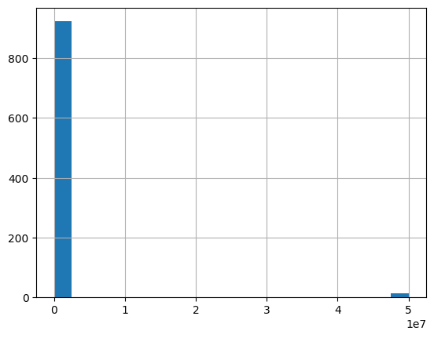

```python
data.annual_income.hist(bins = 20)
plt.show()
```

```python
data.annual_income.sort_values().value_counts()
```

```
annual_income
50000000.0    14
15000.0        7
65416.0        3
38058.0        2
53076.0        2
              ..
110762.0       1
111314.0       1
119291.0       1
119812.0       1
23232.0        1
Name: count, Length: 913, dtype: int64
```

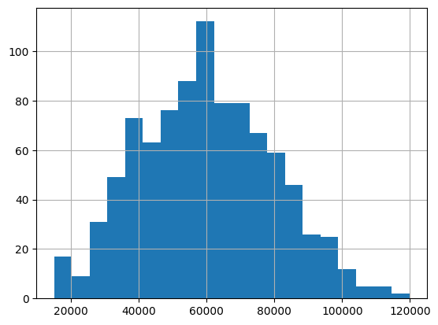

```python
data.loc[data.annual_income>200000,['annual_income']] = np.nan
data.annual_income.hist(bins = 20)
plt.show()
```

## Missing Value Patterns

- If a large amount of data is missing, imputation may not be appropriate.
- Data may be missing for a reason. This may be apparent from the pattern of missing values. Ideally, only data that is missing completely at random should be imputed.

#### Missing Data Frequency

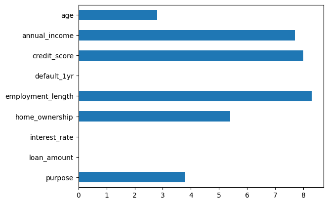

```python
data.isnull().mean().mul(100)\
.sort_index(ascending = False)\
.plot(kind = 'barh')
plt.show()
```

#### Missing Data Heatmap

The pattern of missing data is likely to shed light on the reasons behind it. For small and medium datasets, it is possible to visualize missing data in a chart such as a heatmap.

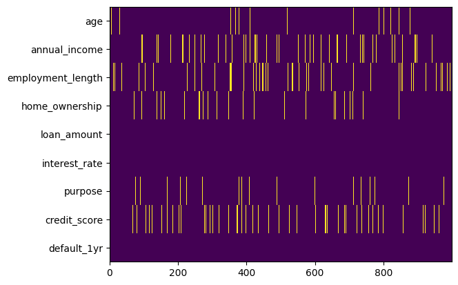

```python
heatmap_mat = data.isna().astype(int).T
plt.imshow(heatmap_mat, aspect = 'auto', interpolation='none')
plt.yticks(range(heatmap_mat.shape[0]), heatmap_mat.index)
plt.show()
```

#### Correlations Heatmap

missingno contains a number of handy functions to explore and visualizing missing data.

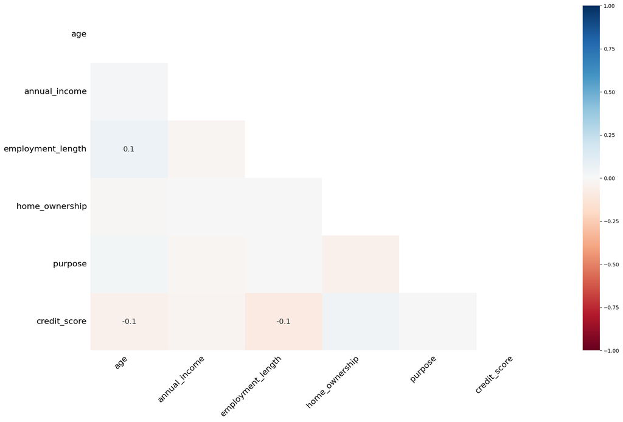

```python
import missingno as msno
msno.heatmap(data)
plt.show()
```

## Solutions to Missing Data

Before we examine solutions, it is worth noting that while many popular predictive models such as linear regression, penalized regression models, support vector machines and neural networks cannot tolerate any amount of missing values, there are a few predictive models such as classification and regression trees and other tree-based models that can handle incomplete data.

For the vast majority of predictive models and also a number unsupervised learning methods, missing values need to be addressed. There are three broad categories of solutions,  
(a) delete (or ignore) missing values,  
(b) encode missing data,  
(c) impute.

### Delete Missing Data

- Pairwise deletion: Remove missing observations only if they are missing for the features that are part of the analysis. pandas and numpy do this by default.
- Listwise deletion: Remove entire row observation (row) if data is missing on any feature

```python
print(
    data.age.head(8)
)

data.age.mean()   # Missing values are automatically ignored in pandas
```

```
0    51.0
1    39.0
2    51.0
3    33.0
4    24.0
5     NaN
6    33.0
7    53.0
Name: age, dtype: float64
```

```
np.float64(47.739711934156375)
```

```python
data.dropna(subset = 'age',how = 'any').head(8)   # drop entire row if there is even one value missing for income
```

|  | age | annual_income | employment_length | home_ownership | loan_amount | interest_rate | purpose | credit_score | default_1yr |
| --- | --- | --- | --- | --- | --- | --- | --- | --- | --- |
| 0 | 51.0 | 55597.0 | <1 year | Rent | 7572.0 | 7.97 | Home improvement | 635.0 | 0 |
| 1 | 39.0 | NaN | 10+ years | Own | 7458.0 | 14.27 | Education | 667.0 | 0 |
| 2 | 51.0 | 69558.0 | 3–5 years | Own | 16220.0 | 14.88 | Home improvement | 663.0 | 0 |
| 3 | 33.0 | 87347.0 | 1–3 years | Own | 19919.0 | 12.59 | Home improvement | 656.0 | 0 |
| 4 | 24.0 | 68641.0 | 3–5 years | Mortgage | 18188.0 | 13.74 | NaN | 730.0 | 0 |
| 6 | 33.0 | 58708.0 | 5–10 years | Mortgage | 16165.0 | 16.30 | Car | 695.0 | 0 |
| 7 | 53.0 | 29032.0 | 3–5 years | Rent | 12001.0 | 11.71 | Debt consolidation | 645.0 | 0 |
| 8 | 43.0 | 41279.0 | 10+ years | Own | 9499.0 | 9.93 | NaN | 652.0 | 0 |

### Encode and Impute

#### Simple Imputation

```python
num_feat = ['age', 'annual_income','credit_score']
num_feat_ind = ['i_age', 'i_annual_income','i_credit_score']
cat_feat = ['employment_length','home_ownership','purpose']
cat_feat_ind = ['i_employment_length','i_home_ownership','i_purpose']

from sklearn.impute import SimpleImputer
impute_mean = SimpleImputer(strategy = 'mean', add_indicator=True)
impute_median = SimpleImputer(strategy = 'median', add_indicator=True)
impute_mode = SimpleImputer(strategy = 'most_frequent', add_indicator=True)
impute_constant = SimpleImputer(strategy = 'constant',fill_value=0)

data_imputed_simple = data.copy()
data_imputed_simple[num_feat+num_feat_ind] = impute_mean.fit_transform(data[num_feat])
data_imputed_simple[cat_feat+cat_feat_ind] = impute_mode.fit_transform(data[cat_feat])
data_imputed_simple.head()
```

|  | age | annual_income | employment_length | home_ownership | loan_amount | interest_rate | purpose | credit_score | default_1yr | i_age | i_annual_income | i_credit_score | i_employment_length | i_home_ownership | i_purpose |
| --- | --- | --- | --- | --- | --- | --- | --- | --- | --- | --- | --- | --- | --- | --- | --- |
| 0 | 51.0 | 55597.000000 | <1 year | Rent | 7572.0 | 7.97 | Home improvement | 635.0 | 0 | 0.0 | 0.0 | 0.0 | False | False | False |
| 1 | 39.0 | 60079.781148 | 10+ years | Own | 7458.0 | 14.27 | Education | 667.0 | 0 | 0.0 | 1.0 | 0.0 | False | False | False |
| 2 | 51.0 | 69558.000000 | 3–5 years | Own | 16220.0 | 14.88 | Home improvement | 663.0 | 0 | 0.0 | 0.0 | 0.0 | False | False | False |
| 3 | 33.0 | 87347.000000 | 1–3 years | Own | 19919.0 | 12.59 | Home improvement | 656.0 | 0 | 0.0 | 0.0 | 0.0 | False | False | False |
| 4 | 24.0 | 68641.000000 | 3–5 years | Mortgage | 18188.0 | 13.74 | Debt consolidation | 730.0 | 0 | 0.0 | 0.0 | 0.0 | False | False | True |

#### Nearest Neighbor

```python
from sklearn.impute import KNNImputer
impute_knn = KNNImputer(n_neighbors=5, add_indicator=True)

data_imputed_knn = data.copy()
data_imputed_knn[num_feat+num_feat_ind] = impute_knn.fit_transform(data[num_feat])
data_imputed_knn[cat_feat+cat_feat_ind] = impute_mode.fit_transform(data[cat_feat])
data_imputed_knn.head()
```

|  | age | annual_income | employment_length | home_ownership | loan_amount | interest_rate | purpose | credit_score | default_1yr | i_age | i_annual_income | i_credit_score | i_employment_length | i_home_ownership | i_purpose |
| --- | --- | --- | --- | --- | --- | --- | --- | --- | --- | --- | --- | --- | --- | --- | --- |
| 0 | 51.0 | 55597.0 | <1 year | Rent | 7572.0 | 7.97 | Home improvement | 635.0 | 0 | 0.0 | 0.0 | 0.0 | False | False | False |
| 1 | 39.0 | 46979.8 | 10+ years | Own | 7458.0 | 14.27 | Education | 667.0 | 0 | 0.0 | 1.0 | 0.0 | False | False | False |
| 2 | 51.0 | 69558.0 | 3–5 years | Own | 16220.0 | 14.88 | Home improvement | 663.0 | 0 | 0.0 | 0.0 | 0.0 | False | False | False |
| 3 | 33.0 | 87347.0 | 1–3 years | Own | 19919.0 | 12.59 | Home improvement | 656.0 | 0 | 0.0 | 0.0 | 0.0 | False | False | False |
| 4 | 24.0 | 68641.0 | 3–5 years | Mortgage | 18188.0 | 13.74 | Debt consolidation | 730.0 | 0 | 0.0 | 0.0 | 0.0 | False | False | True |

#### MICE

```python
from sklearn.experimental import enable_iterative_imputer
from sklearn.impute import IterativeImputer
impute_mice = IterativeImputer(max_iter = 1000, add_indicator=True,random_state = 1031)

data_imputed_mice = data.copy()
data_imputed_mice[num_feat+num_feat_ind] = impute_mice.fit_transform(data[num_feat])
data_imputed_mice[cat_feat+cat_feat_ind] = impute_mode.fit_transform(data[cat_feat])
data_imputed_mice.head()
```

|  | age | annual_income | employment_length | home_ownership | loan_amount | interest_rate | purpose | credit_score | default_1yr | i_age | i_annual_income | i_credit_score | i_employment_length | i_home_ownership | i_purpose |
| --- | --- | --- | --- | --- | --- | --- | --- | --- | --- | --- | --- | --- | --- | --- | --- |
| 0 | 51.0 | 55597.000000 | <1 year | Rent | 7572.0 | 7.97 | Home improvement | 635.0 | 0 | 0.0 | 0.0 | 0.0 | False | False | False |
| 1 | 39.0 | 60079.841048 | 10+ years | Own | 7458.0 | 14.27 | Education | 667.0 | 0 | 0.0 | 1.0 | 0.0 | False | False | False |
| 2 | 51.0 | 69558.000000 | 3–5 years | Own | 16220.0 | 14.88 | Home improvement | 663.0 | 0 | 0.0 | 0.0 | 0.0 | False | False | False |
| 3 | 33.0 | 87347.000000 | 1–3 years | Own | 19919.0 | 12.59 | Home improvement | 656.0 | 0 | 0.0 | 0.0 | 0.0 | False | False | False |
| 4 | 24.0 | 68641.000000 | 3–5 years | Mortgage | 18188.0 | 13.74 | Debt consolidation | 730.0 | 0 | 0.0 | 0.0 | 0.0 | False | False | True |

## Impute Time Series Data

Above methods are not suitable for data that changes over time.

```python
trends = pd.read_csv('trends_python.csv',skiprows=2,parse_dates=['Day']).set_index(['Day'])
trends.columns = ['searches']
trends.loc['2025-02-08':'2025-02-14'] = np.nan
trends.loc['2025-03-29':'2025-04-10'] = np.nan
trends.loc['2025-04-15':'2025-04-19'] = np.nan
trends.loc['2025-02-01': '2025-02-14']
```

| Day | searches |
| --- | --- |
| 2025-02-01 | 51.0 |
| 2025-02-02 | 51.0 |
| 2025-02-03 | 88.0 |
| 2025-02-04 | 95.0 |
| 2025-02-05 | 98.0 |
| 2025-02-06 | 94.0 |
| 2025-02-07 | 89.0 |
| 2025-02-08 | NaN |
| 2025-02-09 | NaN |
| 2025-02-10 | NaN |
| 2025-02-11 | NaN |
| 2025-02-12 | NaN |
| 2025-02-13 | NaN |
| 2025-02-14 | NaN |

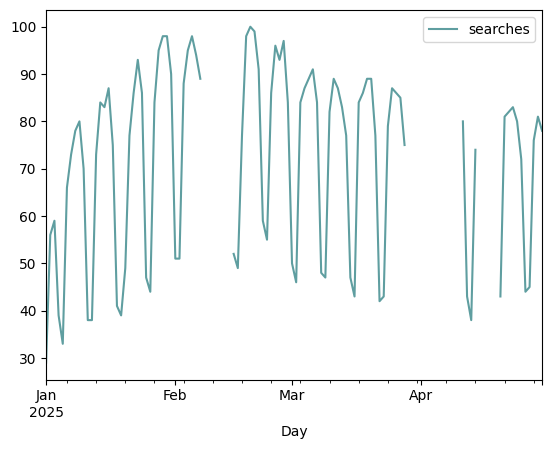

```python
trends.plot(color = 'cadetblue')
```

### Imputation Methods for Time Series

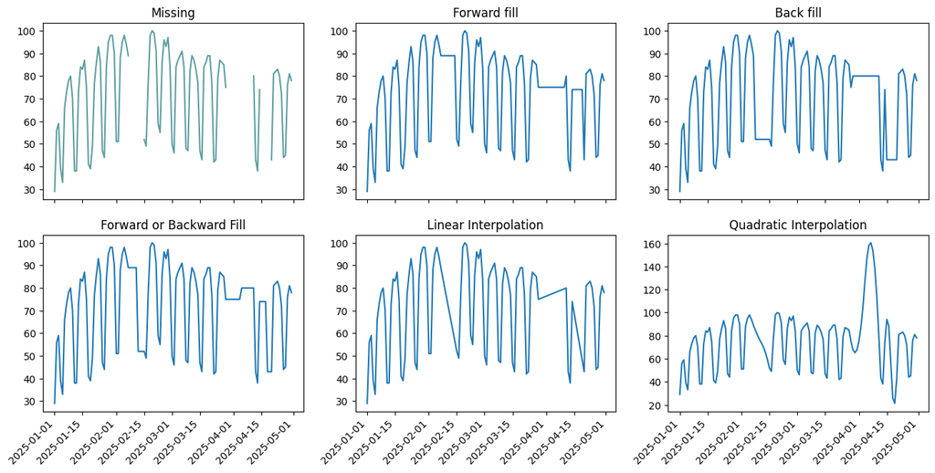

```python
fig, axs = plt.subplots(2, 3,figsize = (16,8), sharex = True)
trends['imputed'] = trends.searches.ffill()

axs[0, 0].plot(trends.searches, color = 'cadetblue')
axs[0, 0].set_title('Missing')
axs[0, 1].plot(trends.searches.ffill())
axs[0, 1].set_title('Forward fill')
axs[0, 2].plot(trends.searches.bfill())
axs[0, 2].set_title('Back fill')
axs[1, 0].plot(trends.searches.interpolate(method = 'nearest'))
axs[1, 0].set_title('Forward or Backward Fill')
axs[1, 1].plot(trends.searches.interpolate(method = 'linear'))
axs[1, 1].set_title('Linear Interpolation')
axs[1, 2].plot(trends.searches.interpolate(method = 'polynomial',order = 2)) # or method = 'spline'
axs[1, 2].set_title('Quadratic Interpolation')
fig.autofmt_xdate(rotation = 45)
plt.show()
```

## Summary

This note examined  
- missing value types  
- methods to inspect missing values  
- imputation methods for cross-sectional data  
- imputation methods for time series data

This file was generated using Python 3.13.5 on Windows 10 with the following libraries: matplotlib 3.10.3, missingno 0.5.2, numpy 2.3.1, pandas 2.3.0, scikit-learn 1.7.1